# Análisis de películas de Netflix

Juana Mir, Sonia Trabado y Lucía Guastoni

23/12/2020

Este documento presenta el análisis del dataset de películas de Netflix. Se muestra una extensa sucesión de películas con multitud de valoraciones. De ellas se extraen 250 películas de forma aleatoria con sus correspondientes valoraciones y datos adjuntos, como por ejemplo; año de estreno, día-mes-año de valoración, puntuación que se le ha dado a la película, etc.

A lo largo de todo el estudio se van a realizar una serie de transformaciones en los datos proporcionados, se van a calcular determinados datos estadísticos y se mostrarán diferentes gráficos. Todo ello para obtener y entender mejor la información que aportan los datos.

## Parte 1: Limpieza y carga de datos

```r
for(i in 1:4){
  netflix <- read_tsv(paste0("../Data/combined_data_",i,".txt"),n_max = Inf,col_names = FALSE)
  netflix <- netflix%>% mutate(fila=row_number())
  filas <- grep(":",netflix$X1)

  filas_ID <-  netflix %>%
    filter( fila %in% filas ) %>%
    mutate(ID=as.integer(gsub(":","",X1)))

  reps <- diff(c(filas_ID$fila,max(netflix$fila)+1))
  filas_ID <- filas_ID %>% mutate(fila_final=c(filas_ID$fila[-1]-1,dim(netflix)[1]),file_num=rep(i,dim(filas_ID)[1]))
write_csv(filas_ID,paste0("../Data/filas_ID_combined_",i,".txt"))
}

filas_all=read_csv(paste0("../Data/filas_ID_combined_",1,".txt"),n_max = Inf,col_names = TRUE)

for(i in 2:4){
  filas_all=rbind(filas_all,read_csv(paste0("../Data/filas_ID_combined_",i,".txt"),n_max = Inf,col_names = TRUE))
}

write_csv(netflix, "netflix.csv")
```

Formato de columnas:

```r
cols(
X1 = col_character(),
fila = col_double(),
ID = col_double(),
fila_final = col_double(),
data = col_double()
 )

glimpse(filas_all)

table(filas_all$file_num)
```

Seleccion de columnas:

```r
set.seed(498196)

muestra_grupo <- sort(sample(1:17770, 250, replace = FALSE))

filas_grupo <- filas_all[which(rownames(filas_all)%in%muestra_grupo),]
filas_grupo$cant_filas <- filas_grupo$fila_final - filas_grupo$fila

valoraciones_por_archivo <- filas_grupo %>%
  group_by(file_num) %>%
  summarise(cant_valoraciones = sum(cant_filas))

valoraciones_por_archivo <- rbind(valoraciones_por_archivo, c("total",sum(valoraciones_por_archivo$cant_valoraciones)))
valoraciones_por_archivo$cant_valoraciones <- as.integer(valoraciones_por_archivo$cant_valoraciones)
```

Filtramos las 250 películas que nos han tocado segun nuestra seed:

```r
valoraciones_1 <- data.frame()
for (i in muestra_grupo){
d <- read_tsv(paste0("../Data/combined_data_", filas_all$file_num[i], ".txt"), skip = filas_all$fila[i] , col_names = FALSE)
valoraciones_int <- slice(d, 1 : (filas_all$fila_final[i] - filas_all$fila[i]))
valoraciones_int$id_pelicula <- rep(filas_all$ID[i], (filas_all$fila_final[i] -  filas_all$fila[i]))
valoraciones_1 <- rbind(valoraciones_1, valoraciones_int)
}
```

Damos formato al dataframe con las películas ya filtradas:

```r
peliculas <- valoraciones_1 %>%
  separate(X1_1,into=c("user_id", "score", "fecha"), sep=",") %>%
  mutate(score=as.integer(score)) %>%
  mutate(id_pelicula=as.numeric(id_pelicula)) %>%
  # select(peliculas, -1) no funciona!!

peliculas <- select(peliculas, -1)
```

Controlamos que la cantidad de películas filtradas sea 250:

```r
valoraciones_por_archivo[5,2] - dim(peliculas)[1]
```

Cargamos el csv que contiene el nombre de las peliculas y separamos la información por columnas:

```r
movie_titles=read_tsv("../Data/movie_titles.csv",
                      locale = readr::locale(encoding = "ISO-8859-1"),
                      col_names=FALSE)

movie_titles=movie_titles %>% separate(X1,",",into =c("id_pelicula","año","titulo"),extra="merge")
```

Combinamos la tabla de los nombres de las películas con el dataframe de valoraciones:

```r
peliculas_con_nombre <- merge.data.frame(peliculas, movie_titles, by = "id_pelicula")
write.csv(peliculas_con_nombre, "peliculas_filtradas_con_nombre.csv", row.names = F)
```

## Parte 2: Exploratory Data Analysis (EDA)

```r
df <- read.csv("../Data/peliculas_filtradas_con_nombre.csv")
peliculas <- as_tibble(df)
str(peliculas)
```

```
tibble [1,468,808 x 6] (S3: tbl_df/tbl/data.frame)
 $ id_pelicula: int [1:1468808] 37 37 37 37 37 37 37 37 37 37 ...
 $ user_id    : int [1:1468808] 41412 1033971 724592 126998 2625420 353906 640322 1208081 818736 12451 ...
 $ score      : int [1:1468808] 3 5 5 3 2 3 5 5 3 4 ...
 $ fecha      : chr [1:1468808] "2004-09-27" "2005-03-17" "2005-09-07" "2004-09-30" ...
 $ año        : int [1:1468808] 1973 1973 1973 1973 1973 1973 1973 1973 1973 1973 ...
 $ titulo     : chr [1:1468808] "Zatoichi's Conspiracy" "Zatoichi's Conspiracy" "Zatoichi's Conspiracy" "Zatoichi's Conspiracy" ...
```

### 1) Justifica para cada una de las variables de la tabla anterior el tipo de dato que mejor se ajusta a cada una de ellas: numérico, ordinal, categórico…

Este conjunto de datos consta de 250 películas, disponibles en Netflix prize data, y contiene 6 variables y 1.468.808 observaciones. El tipo de dato de las variables “id_pelicula”, “user_id”, “año” y “score” es numeros enteros. Estas variables son el identificador de la pelicula, el identificador del usuario que puntua, el año de estreno de la pelicula y la valoracion asignada, respectivamente. Las variables “titulo” e “fecha”, son de tipo character, esto significa que son texto. La primera indica el nombre de la pelicula y “fecha” se refiere al dia, mes y año en que el usuario ha realizado su puntuación.

En las tablas a continuacion mostramos una breve descripcion de cada variable. La primera tabla nos muestra la cantidad de valores unicos de cada una de las variables. La segunda tabla contiene un resumen de los principales estadisticos de interes para las variables numericas. La tercera tabla muestra informacion de las variables que son de tipo character.

```r
knitr::kable(peliculas %>% summarise_all(n_distinct), caption =  "Cantidad de valores únicos por variable") %>%
  column_spec (1:6,border_left = T, border_right = T) %>%
  kableExtra::row_spec(1, extra_css = "border-bottom: 1px solid") %>%
  kable_styling()
```

Cantidad de valores únicos por variable

| id_pelicula | user_id | score | fecha | año | titulo |
| --- | --- | --- | --- | --- | --- |
| 250 | 357175 | 5 | 2173 | 50 | 250 |

```r
peliculas %>%
  select(-c(titulo, fecha )) %>%
  sapply(summary) %>%
  knitr::kable(caption = "Resumen de los principales estadísticos de las variables númericas") %>%
  column_spec (1:5,border_left = T, border_right = T) %>%
  kableExtra::row_spec(6, extra_css = "border-bottom: 1px solid") %>%
  kable_styling()
```

Resumen de los principales estadísticos de las variables númericas

|  | id_pelicula | user_id | score | año |
| --- | --- | --- | --- | --- |
| Min. | 37.000 | 6 | 1.000000 | 1915.000 |
| 1st Qu. | 6347.000 | 661089 | 3.000000 | 1992.000 |
| Median | 8989.000 | 1319892 | 4.000000 | 1999.000 |
| Mean | 9949.423 | 1322524 | 3.537419 | 1994.532 |
| 3rd Qu. | 15057.000 | 1983669 | 4.000000 | 2002.000 |
| Max. | 17759.000 | 2649429 | 5.000000 | 2005.000 |

```r
peliculas %>%
  select(c(titulo, fecha )) %>%
  sapply(summary) %>%
  knitr::kable(caption = "Información de las variables tipo character") %>%
  column_spec (1:3,border_left = T, border_right = T) %>%
  kableExtra::row_spec(3, extra_css = "border-bottom: 1px solid") %>%
  kable_styling()
```

Información de las variables tipo character

|  | titulo | fecha |
| --- | --- | --- |
| Length | 1468808 | 1468808 |
| Class | character | character |
| Mode | character | character |

### 2) Estudia la distribución del numero de películas estrenadas por año. Realiza un gráfico de muestre esta distribución haciendo los ajustes necesarios (agrupaciones, cambios de escala, transformaciones…)

```r
estrenos_por_año <- arrange((peliculas %>%
                        group_by(año) %>%
                        summarise(cantidad_estrenos = n_distinct(id_pelicula))))
```

En el gráfico a continuación vemos la distribución de las películas por año de estreno:

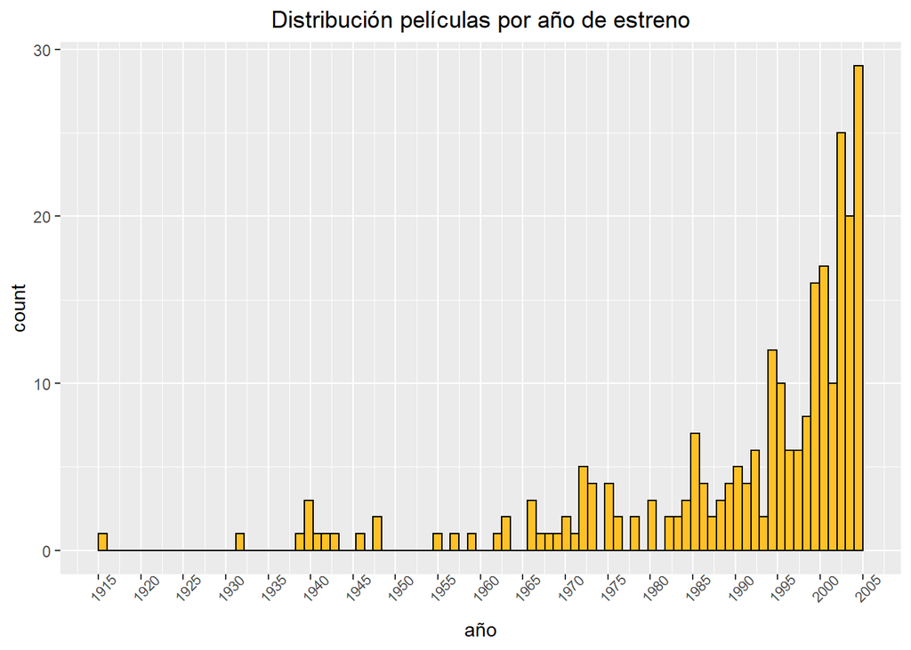

```r
peliculas_unique <- distinct(peliculas, id_pelicula, año)

ggplot(peliculas_unique) +
  geom_histogram(peliculas_unique, mapping = aes(x=año, fill = año), bins = 90, fill = "goldenrod1", color = "black", boundary = 1915) +
  ggtitle ("Distribución películas por año de estreno")+
  theme(plot.title = element_text(hjust = 0.5)) +
  scale_x_continuous(breaks = seq(1915,2005,5), labels = as.integer(seq(1915,2005,5))) +
  theme(axis.text.x = element_text(size = 8, angle = 45))
```

A simple vista puede observarse que la distribución de la cantidad de películas estrenadas por año está sesgada hacia la derecha, es decir, hay pocas películas que han sido estrenadas más de 40 o 50 años atrás, mientras que cuanto mas reciente es el año, mayor es la cantidad de películas estrenadas.

Por lo tanto, para poder visualizar mejor los estrenos, realizamos un gráfico que agrupe en cada barra 5 años consecutivos, siguiendo la regla de Freedman–Diaconis:

$$Bin width = 2 * {\frac{IQR(x)}{\sqrt[3]{n}}}$$

```r
bw <- 2 * IQR(peliculas_unique$año) / length(peliculas_unique$año)^(1/3)

peliculas_unique %>%
  mutate(ints = cut(año, breaks = 18, dig.lab = 5)) %>%
  group_by(ints) %>%
  summarise(cantidad_estrenos = n_distinct(id_pelicula),
            porcentaje = paste0(round(cantidad_estrenos/250*100,2),"%")) %>%
  knitr::kable(caption = "Bins") %>%
  column_spec (1:3,border_left = T, border_right = T) %>%
  kableExtra::row_spec(16, extra_css = "border-bottom: 1px solid") %>%
  kable_styling()
```

Bins

| ints | cantidad_estrenos | porcentaje |
| --- | --- | --- |
| (1914.9,1920] | 1 | 0.4% |
| (1930,1935] | 1 | 0.4% |
| (1935,1940] | 4 | 1.6% |
| (1940,1945] | 3 | 1.2% |
| (1945,1950] | 3 | 1.2% |
| (1950,1955] | 1 | 0.4% |
| (1955,1960] | 2 | 0.8% |
| (1960,1965] | 3 | 1.2% |
| (1965,1970] | 8 | 3.2% |
| (1970,1975] | 14 | 5.6% |
| (1975,1980] | 7 | 2.8% |
| (1980,1985] | 14 | 5.6% |
| (1985,1990] | 18 | 7.2% |
| (1990,1995] | 34 | 13.6% |
| (1995,2000] | 53 | 21.2% |
| (2000,2005.1] | 84 | 33.6% |

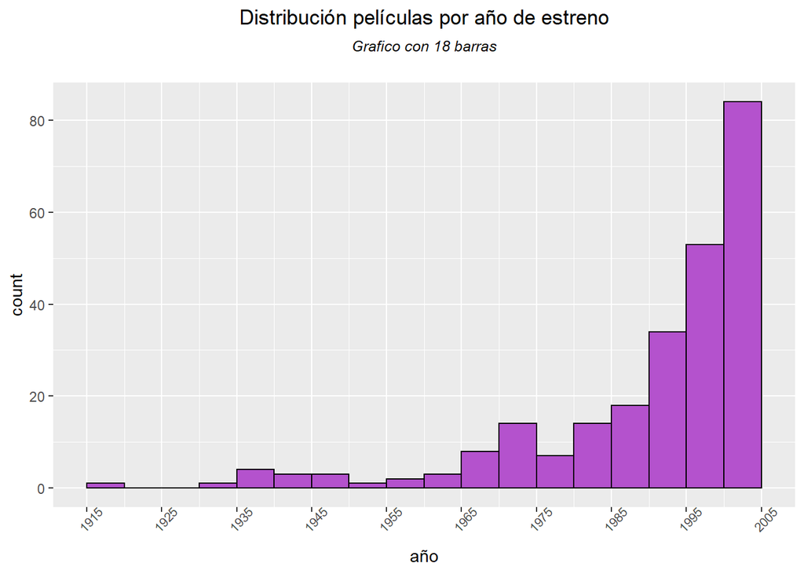

```r
ggplot(peliculas_unique) +
geom_histogram(mapping = aes(x = año), fill = "mediumorchid3", color = "black", binwidth = 5, boundary=1915) +
  ggtitle(expression(atop("Distribución películas por año de estreno", atop(italic("Grafico con 18 barras"), ""))))+
  theme(plot.title = element_text(hjust = 0.5)) +
  scale_x_continuous(breaks = seq(1915,2005,10), labels = as.integer(seq(1915,2005, 10))) +
  theme(axis.text.x = element_text(size = 8, angle = 45))
```

Inclusive, agrupando 15 años en cada barra, tenemos:

```r
peliculas_unique %>%
  mutate(ints = cut(año, breaks = 6, dig.lab = 5)) %>%
  group_by(ints) %>%
  summarise(cantidad_estrenos = n_distinct(id_pelicula),
            porcentaje = paste0(round(cantidad_estrenos/250*100,2),"%")) %>%
  knitr::kable(caption = "Bins") %>%
  column_spec (1:3,border_left = T, border_right = T) %>%
  kableExtra::row_spec(6, extra_css = "border-bottom: 1px solid") %>%
  kable_styling()
```

Bins

| ints | cantidad_estrenos | porcentaje |
| --- | --- | --- |
| (1914.9,1930] | 1 | 0.4% |
| (1930,1945] | 8 | 3.2% |
| (1945,1960] | 6 | 2.4% |
| (1960,1975] | 25 | 10% |
| (1975,1990] | 39 | 15.6% |
| (1990,2005.1] | 171 | 68.4% |

Donde claramente puede verse que casi el 70% de las películas han sido estrenadas en los últimos 15 años. Gráficamente:

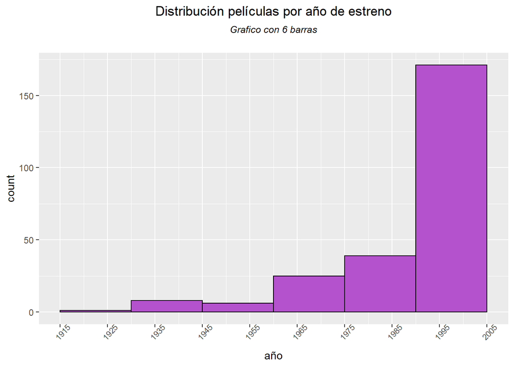

```r
ggplot(peliculas_unique) +
geom_histogram(mapping = aes(x = año), fill = "mediumorchid3", color = "black", binwidth = 15, boundary=1915) +
  ggtitle(expression(atop("Distribución películas por año de estreno", atop(italic("Grafico con 6 barras"), ""))))+
  theme(plot.title = element_text(hjust = 0.5)) +
scale_x_continuous(breaks = seq(1915,2005,10), labels = as.integer(seq(1915,2005, 10))) +
  theme(axis.text.x = element_text(size = 8, angle = 45))
```

### 3) Investiga la librería lubridate (o la que consideréis para manipulación de datos) y utilízala para transformar la columna de la fecha de la valoración en varias columnas por ejemplo year,month, week, day_of_week.

```r
peliculas$fecha <- as_date(peliculas$fecha)
peliculas$año_valoracion <- year(peliculas$fecha)
peliculas$mes_valoracion <- month(peliculas$fecha,  label = TRUE, abbr = F)
peliculas$dia_valoracion <- day(peliculas$fecha)
peliculas$dia_semana_valoracion <- wday(peliculas$fecha, label = TRUE, abbr = F)
```

### 4) Genera un tabla que para cada película nos dé el número total de valoraciones, la suma de las valoraciones, la media las valoraciones, y otras estadísticos de interés (desviación típica, moda , mediana).

Generamos una tabla en la que aparecen las 250 películas con diferentes datos estadísticos:

```r
resumen <- arrange((ddply(peliculas, "titulo", summarise, total_valoraciones=length(score), suma=sum(score), media=mean(score), desv_tipica=sd(score), mediana=median(score))), desc(total_valoraciones))
```

A parte calculamos la moda de cada película:

```r
moda <- peliculas %>% group_by(titulo) %>%
                      summarise(moda = mfv(score)) %>%
                      group_by(titulo)
```

Según la tabla anterior, existen 256 modas, lo cual quiere decir que hay películas que tienen más de una moda. Agrupamos la tabla anterior para identificar las películas con dos modas:

```r
multiples_modas <- moda %>%
     group_by(titulo) %>%
     filter(n()>1)
```

Modificamos la agrupación realizada anteriormente para que quede una fila por película, agregando en la misma celda las dos modas, cuando corresponda, y, a continuación, unimos la tabla resumen con la tabla de modas:

```r
moda2 <- peliculas %>% group_by(titulo) %>%
                      summarise(moda = paste(mfv(score), collapse=", ")) %>%
                      group_by(titulo)


resumen_con_moda <- merge(resumen, moda2, by = "titulo")
```

### 5) De las cinco películas con más número total de valoraciones, compara sus estadísticos y distribuciones (histogramas, boxplot, violin plot…)

Comenzamos filtrando las 5 películas que más se han votado:

```r
top_5 <- arrange((as_tibble(resumen_con_moda %>% top_n(5, total_valoraciones))), desc(total_valoraciones))

arrange((as_tibble(resumen_con_moda %>% top_n(5, total_valoraciones))), desc(total_valoraciones)) %>%
  knitr::kable(caption = "Estadísticos de las 5 películas mas valoradas") %>%
   column_spec (1:7,border_left = T, border_right = T) %>%
   kableExtra::row_spec(5, extra_css = "border-bottom: 1px solid") %>%
   kable_styling()
```

Estadísticos de las 5 películas mas valoradas

| titulo | total_valoraciones | suma | media | desv_tipica | mediana | moda |
| --- | --- | --- | --- | --- | --- | --- |
| Sister Act | 148146 | 475516 | 3.209779 | 1.1648678 | 3 | 3 |
| The Terminal | 136919 | 490119 | 3.579627 | 0.9930653 | 4 | 4 |
| Erin Brockovich | 130782 | 498731 | 3.813453 | 0.9325015 | 4 | 4 |
| Road to Perdition | 106020 | 389454 | 3.673401 | 0.8999046 | 4 | 4 |
| Batman | 76601 | 284053 | 3.708215 | 0.9199793 | 4 | 4 |

#### Cantidad de valoraciones

Del filtrado de las 5 películas con más número de valoraciones se extrae que todas ellas han sido valoradas más de 75.000 veces, con una media en la puntuación entre 3,2 y 3,8.

La película que ha recibido más valoraciones, “Sister Act”, es la que menor score medio tiene de las cinco, con un 3,2. Por otro lado, la película que menos valoraciones ha recibido de las cinco es “Batman”, con una media de su puntuación bastante mayor con un 3,7.

En el siguiente gráfico se observa la proporción de las valoraciones para las cinco películas más votadas:

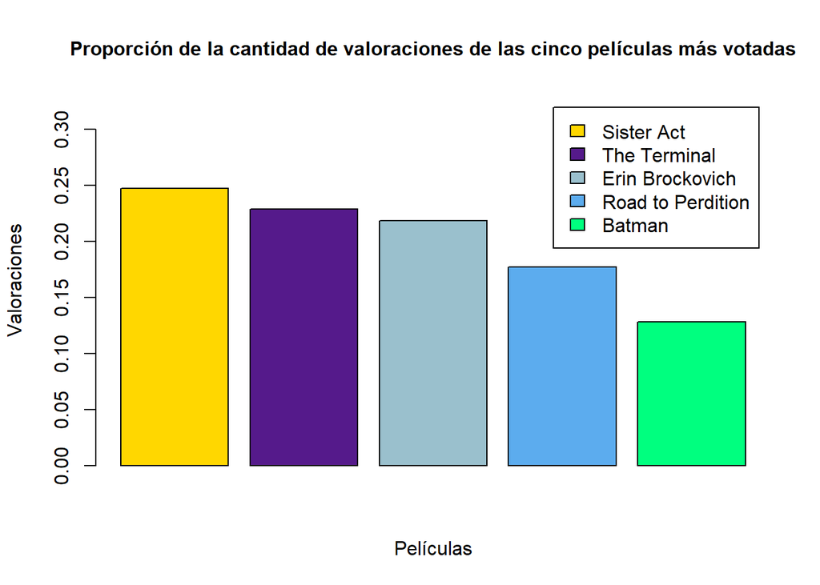

```r
barplot(prop.table(top_5$total_valoraciones),
        col = c("gold1", "purple4", "lightblue3", "steelblue2", "springgreen"),
        legend.text=c("Sister Act","The Terminal", "Erin Brockovich","Road to Perdition", "Batman"),
        ylim=c(0,0.33),
        main="Proporción de la cantidad de valoraciones de las cinco películas más votadas",
        xlab = "Películas", ylab = "Valoraciones",
        cex.main=1)
```

Del grafico anterior puede verse que la pelicula con mas votaciones, “Sister Act”, se lleva el 25% de la cantidad total de valoraciones de las 5 peliculas mas votadas. Contrariamente, “Batman” es la que menos votaciones tiene, con un 13% del total de valoraciones.

#### Valoración y score

El siguiente gráfico relaciona el total de valoraciones con el sumatorio total del score de las cinco películas más votadas. Cuantas más valoraciones ha tenido una película, el sumatorio de todos los scores es más alto. Pero eso no quiere decir que la puntuación sea más alta.

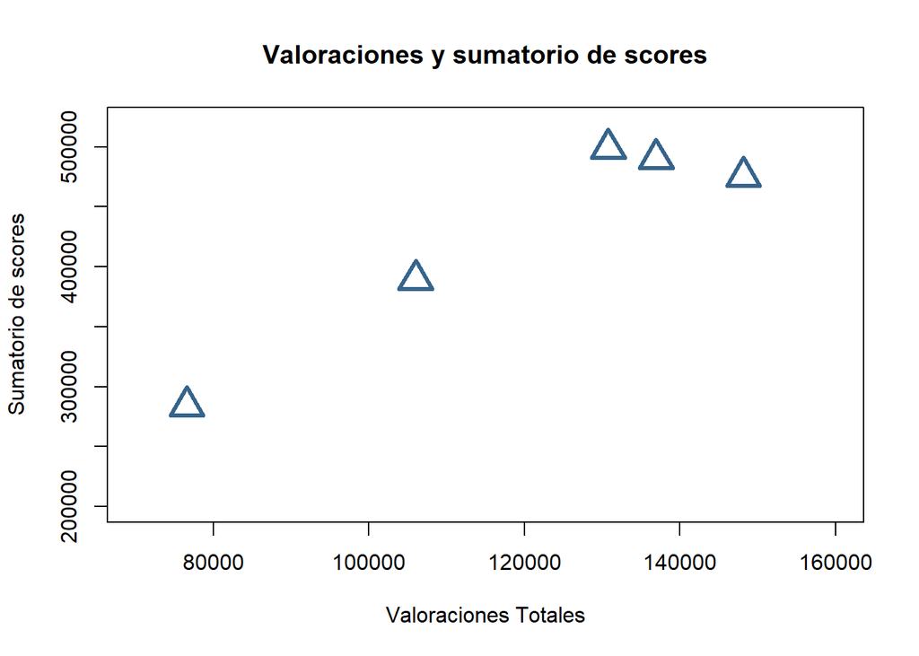

```r
plot(top_5$total_valoraciones, top_5$suma, main = "Valoraciones y sumatorio de scores",
      xlab = "Valoraciones Totales",
      ylab = "Sumatorio de scores",
      pch=2, col="steelblue4",
      lwd=3, cex=2.5,
      xlim=c(70000,160000),
      ylim = c(200000,520000)
      )
```

#### Media y mediana

En el siguiente diagrama de puntos se plasman datos de la media y la mediana. El color de los puntos determina el valor de la mediana de cada película.

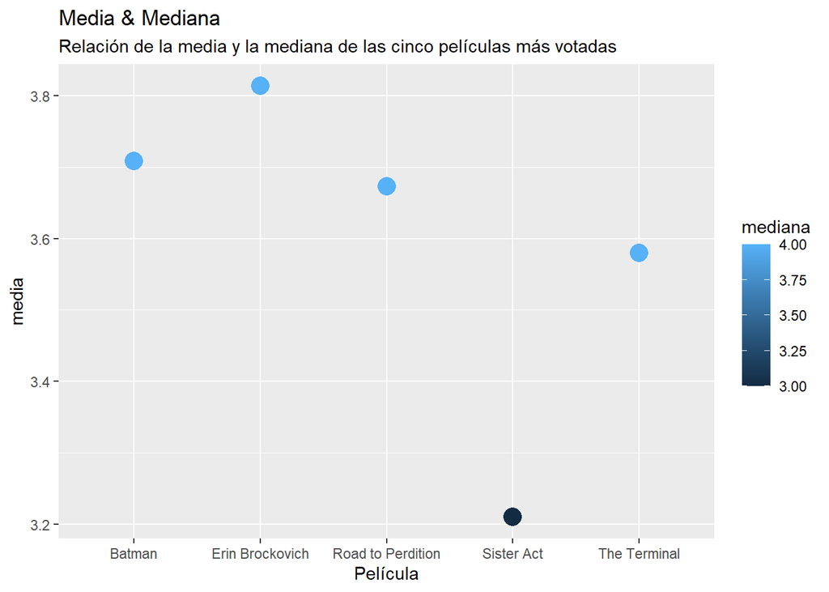

```r
ggplot(data = top_5, mapping = aes(x = titulo, y = media)) +
    geom_point(mapping = aes(color = mediana), size=5) +
    geom_smooth(se = FALSE) +
    labs(
      title = "Media & Mediana",
      subtitle = "Relación de la media y la mediana de las cinco películas más votadas",
      x = "Película"
      )
```

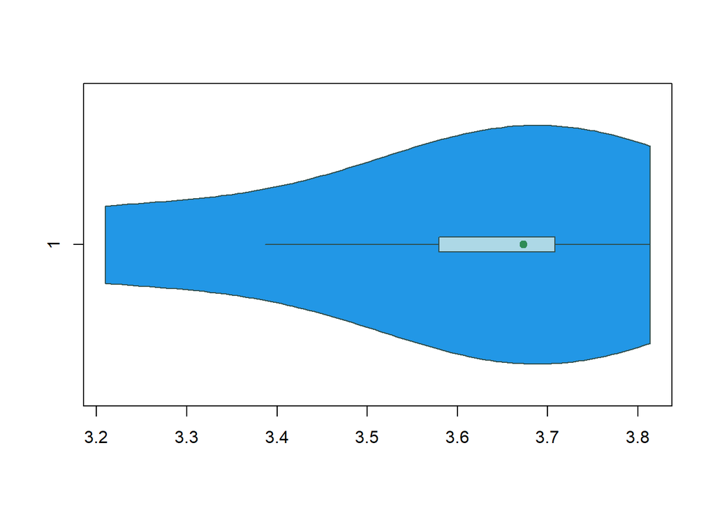

```r
violinplot <- vioplot((top_5$media),
                      horizontal = TRUE,
                      col = 4,
                      rectCol = "lightblue",
                      lineCol = "darkslategrey",
                      colMed = "seagreen",
                      border = "darkslategrey")
```

#### Moda

En este caso se puede ver la moda de las cinco películas más votadas. Coinciden todas con un valor de 4, excepto “Sister Act” que su moda es igual a 3.

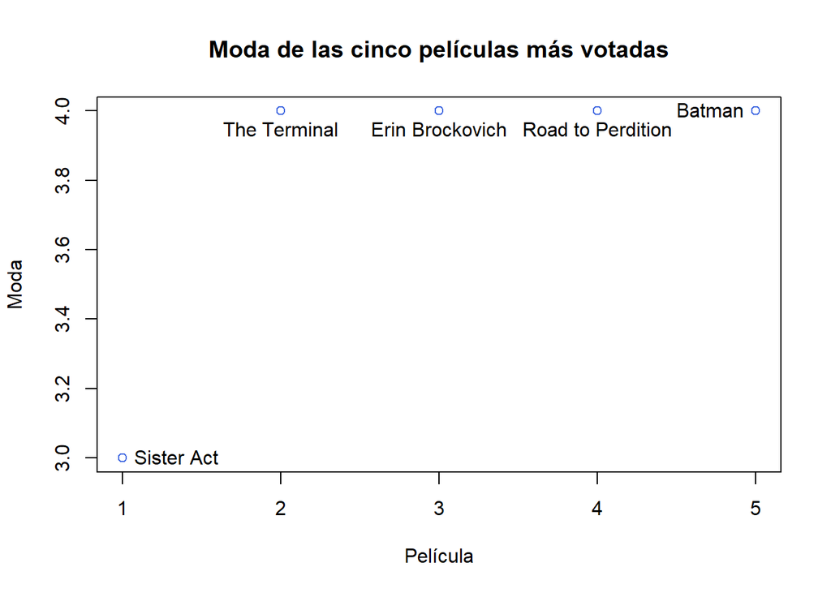

```r
plot(top_5$moda, main = "Moda de las cinco películas más votadas",xlab = "Película", ylab = "Moda", col = "royalblue")
text(1,3, labels = "Sister Act", pos = 4)
text(2,4, labels = "The Terminal", pos = 1)
text(3,4, labels = "Erin Brockovich", pos = 1)
text(4,4, labels = "Road to Perdition", pos = 1)
text(5,4, labels = "Batman", pos = 2)
```

#### Desviación típica

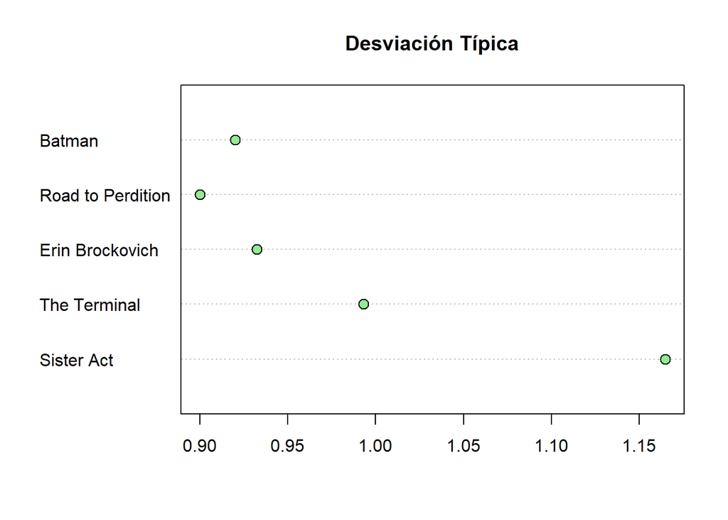

```r
dotchart(top_5$desv_tipica,
          labels = top_5$titulo,
          pch = 21,
          bg = "palegreen2",
          pt.cex = 1.3,
          main = "Desviación Típica")
```

#### Boxplot de las 5 películas más votadas

El gráfico a continuación resume los principales estadisticos antes vistos de las películas:

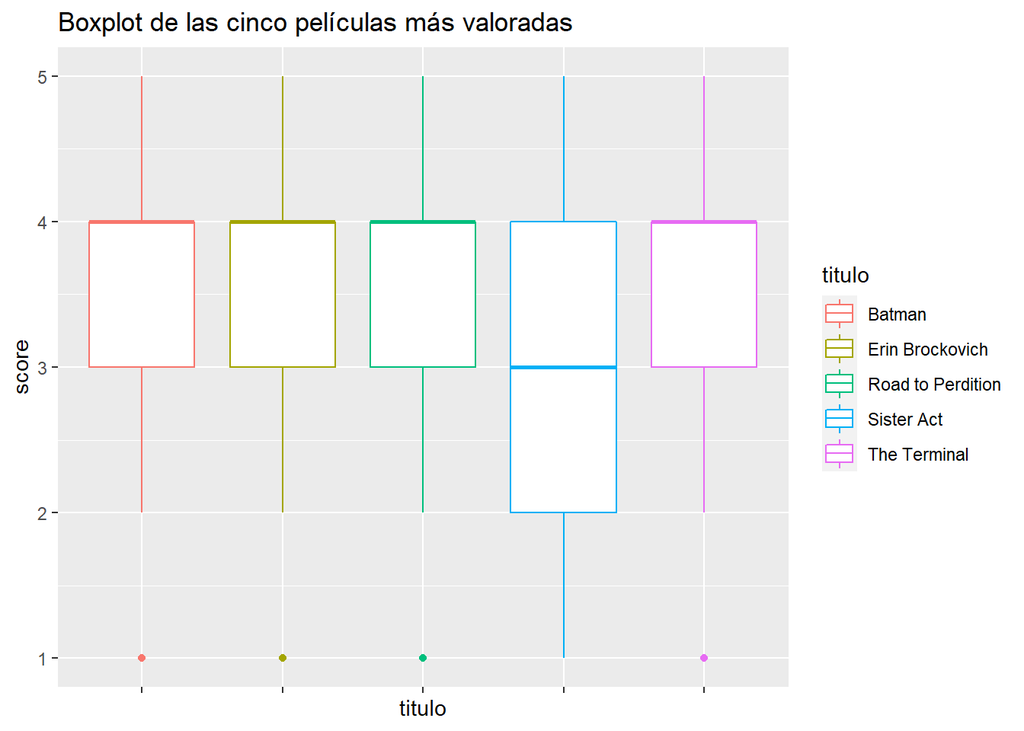

```r
titulos_5 <- unique(top_5$titulo)
top_5_peliculas <- subset(peliculas, titulo %in% titulos_5)

ggplot(top_5_peliculas, aes(x=titulo, y=score, color = titulo)) +
  geom_boxplot() +
  labs(title = "Boxplot de las cinco películas más valoradas") +
  theme(axis.text.x = element_blank())
```

Como podemos ver, en 4 de las 5 películas la mediana y el 3er cuartil coinciden: son iguales a 4. En cambio, en la película “Sister Act”, la mediana es de 3 y el 3er cuartil es 4.

### 6) Investiga la distribución de valoraciones por día de la semana y por mes.¿Qué meses y días de la semana se valoran más películas en netflix?

Comenzamos analizando la distribución de las valoraciones por mes:

```r
knitr::kable(peliculas %>% count(mes_valoracion), col.names = c("Mes", "Cantidad de valoraciones"), caption = "Cantidad de valoraciones por mes") %>%
  kable_styling(bootstrap_options = c("striped", "hover", "condensed"))
```

Cantidad de valoraciones por mes

| Mes | Cantidad de valoraciones |
| --- | --- |
| enero | 118148 |
| febrero | 102813 |
| marzo | 107955 |
| abril | 110445 |
| mayo | 107126 |
| junio | 128087 |
| julio | 135987 |
| agosto | 144394 |
| septiembre | 133913 |
| octubre | 134835 |
| noviembre | 119066 |
| diciembre | 126039 |

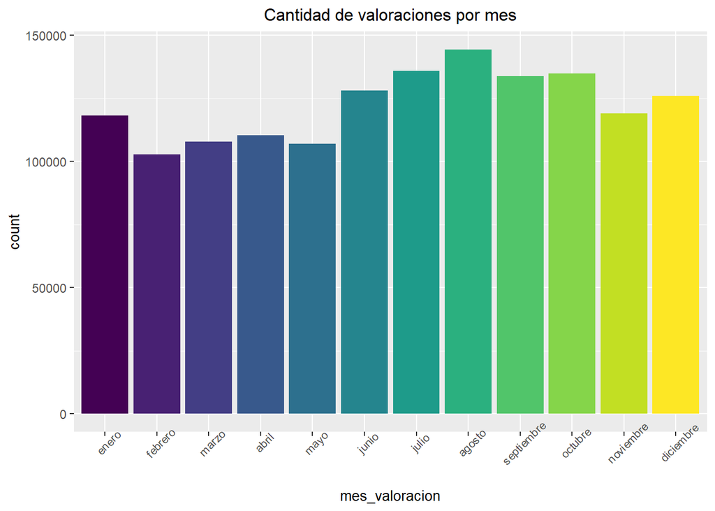

```r
ggplot(data = peliculas) +
  geom_bar(mapping = aes(x = mes_valoracion, fill = mes_valoracion), show.legend = F) +
  labs(title = "Cantidad de valoraciones por mes") +
  theme(plot.title = element_text(size = 12, hjust = 0.5),
        axis.text.x = element_text(size = 8, angle = 45),
        axis.title = element_text(size = 10)
        )
```

Claramente puede observarse que el mes con mayor cantidad de valoraciones es agosto, seguido por julio. Por el contrario, el mes con menos valoraciones es febrero.

Y luego las valoraciones por dia de la semana:

```r
knitr::kable(peliculas %>% count(dia_semana_valoracion), col.names = c("Dia de la semana", "Cantidad de valoraciones"), caption = "Cantidad de valoraciones por día de la semana") %>%
  kable_styling(bootstrap_options = c("striped", "hover", "condensed"))
```

Cantidad de valoraciones por día de la semana

| Dia de la semana | Cantidad de valoraciones |
| --- | --- |
| domingo | 158115 |
| lunes | 252941 |
| martes | 259589 |
| miércoles | 244101 |
| jueves | 216704 |
| viernes | 192570 |
| sábado | 144788 |

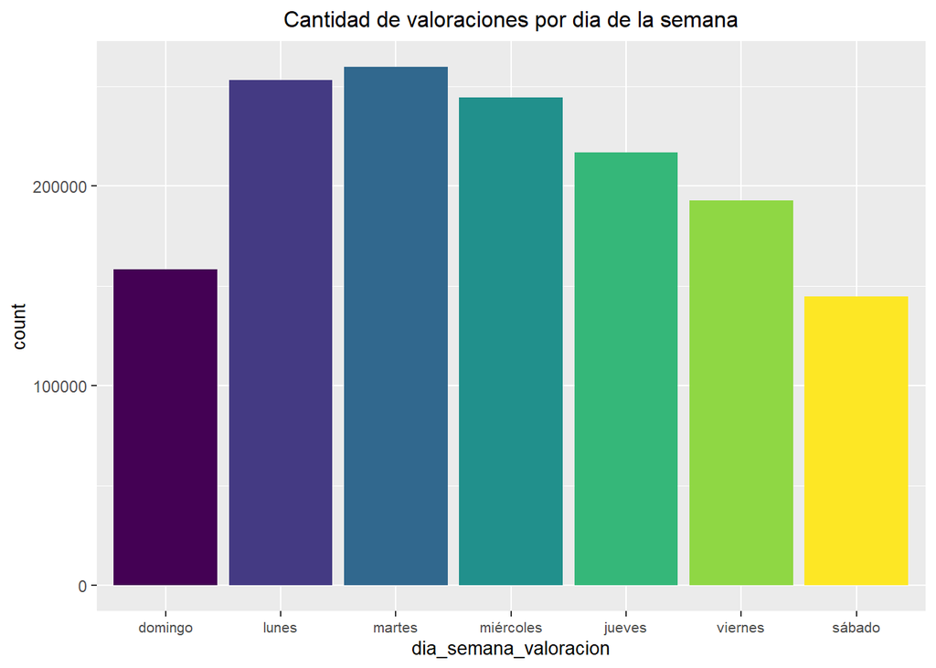

```r
options(scipen=1000)
ggplot(data = peliculas) +
  geom_bar(mapping = aes(x = dia_semana_valoracion, fill = dia_semana_valoracion), show.legend = F) +
  labs(title = "Cantidad de valoraciones por dia de la semana") +
  theme(plot.title = element_text(size = 12, hjust = 0.5),
        axis.text.x = element_text(size = 8),
        axis.title = element_text(size = 10)
        )
```

Vemos que el martes es el día con mayor cantidad de valoraciones. A medida que nos acercamos al sabado, la cantidad de valoraciones va disminuyendo, hasta llegar al dia sabado. Luego, desde el domingo hasta el martes, la cantidad aumenta.

A continuacion cruzamos las variables día de la semana y mes. Los dos siguientes graficos muestran esta informacion:

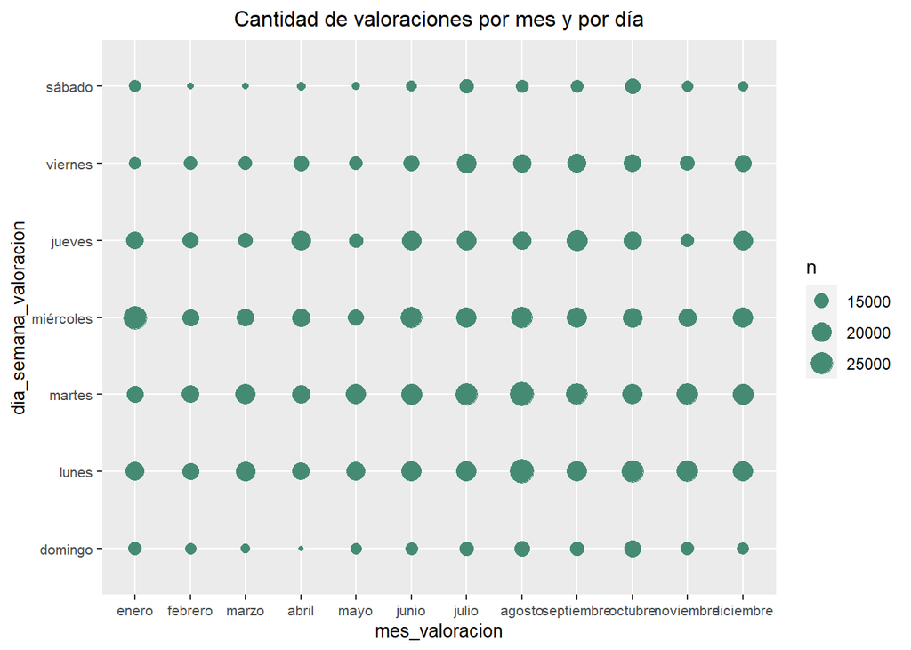

```r
ggplot(data = peliculas) +
  geom_count(mapping = aes(x = mes_valoracion, y = dia_semana_valoracion), color = "aquamarine4") +
  labs(title = "Cantidad de valoraciones por mes y por día") +
  theme(plot.title = element_text(size = 12, hjust = 0.5),
        axis.text = element_text(size = 8),
        axis.title = element_text(size = 10)
        )
```

Puede verse que los días lunes y martes del mes de agosto registran la mayor cantidad de valoraciones, lo cual se deduce a traves del tamaño de los puntos.

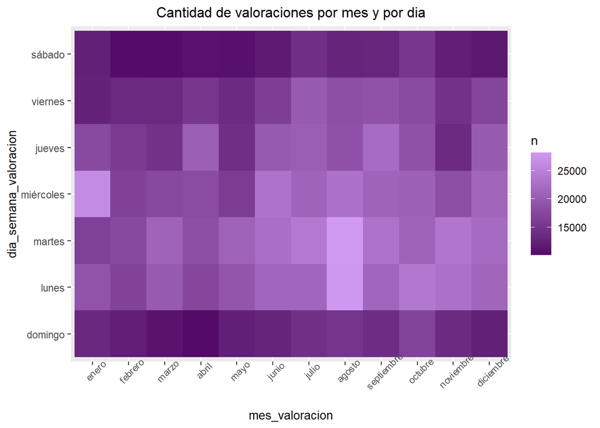

```r
peliculas %>%
  count(mes_valoracion, dia_semana_valoracion) %>%
  ggplot(mapping = aes(x = mes_valoracion, y = dia_semana_valoracion)) +
  geom_tile(mapping = aes(fill = n)) +
  scale_fill_gradient(low = munsell::mnsl("5P 2/12"),
  high = munsell::mnsl("5P 7/12")) +
  labs(title = "Cantidad de valoraciones por mes y por dia") +
  theme(plot.title = element_text(size = 12, hjust = 0.5),
        axis.text.x =  element_text(size = 8, angle = 45),
        axis.title = element_text(size = 10)
        )
```

Como ya hemos dicho anteriormente, el mes de agosto y el día martes se registran mayor cantidad de valoraciones, lo cual puede observarse a traves de los colores más claros del grafico.

### 7) Genera una tabla agrupada por película y año del número de valoraciones. Representa una tabla gráficamente para las 10 películas con mayor número de valoraciones.

```r
valoraciones_por_año <- arrange(peliculas %>%
                                 group_by(titulo, año_valoracion) %>%
                                  summarise(cantidad_valoraciones = n()))

valoraciones_total_año <- head(arrange(valoraciones_por_año %>%
  group_by(titulo) %>%
  summarise(total_valoraciones = sum(cantidad_valoraciones)), desc(total_valoraciones)),10)

top_10 <- unique(valoraciones_total_año$titulo)

top_10_por_año <- subset(valoraciones_por_año, titulo %in% top_10)
n_distinct(top_10_por_año$titulo)
```

```
[1] 10
```

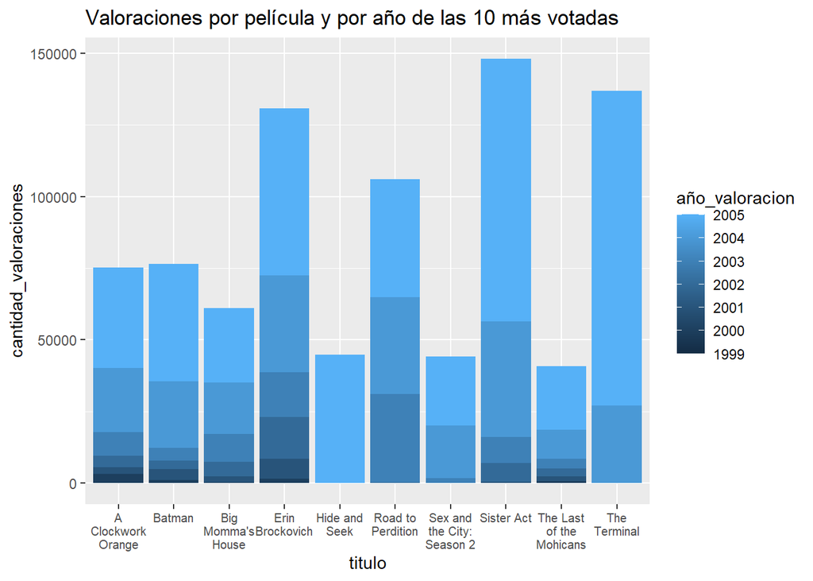

```r
ggplot(top_10_por_año, aes(fill=año_valoracion, y=cantidad_valoraciones, x=titulo)) +
geom_bar(position="stack", stat="identity")+
  labs(title = "Valoraciones por película y por año de las 10 más votadas") +
  theme(axis.text.x = element_text(size = 7.5)) +
  scale_x_discrete(labels = function(x) str_wrap(x, width = 10))
```

Cada barra del gráfico anterior corresponde a una película, y a su vez, cada tonalidad dentro de la misma barra representa la cantidad de películas votadas en cada año. Puede verse que el año 2005 es el año con mayor cantidad de valoraciones, y 1999 el que menos ha tenido. Se ha detectado que la película “Hide and Seek” ha recibido puntuaciones en los años 2004 y 2005, lo cual resulta inconsistente con el año de estreno de la película, que fue en 2005. Posiblemente, el becario se ha equivocado al cargar los datos.

### 8) Distribución del score promedio por año de las 10 películas con mayor número de valoraciones.

```r
media_por_año <- arrange(peliculas %>%
                           group_by(titulo, año_valoracion) %>%
                           summarise(media_valoraciones = mean(score))
                         )

top_10_media_por_año <- subset(media_por_año, titulo %in% top_10)
n_distinct(top_10_por_año$titulo)
```

```
[1] 10
```

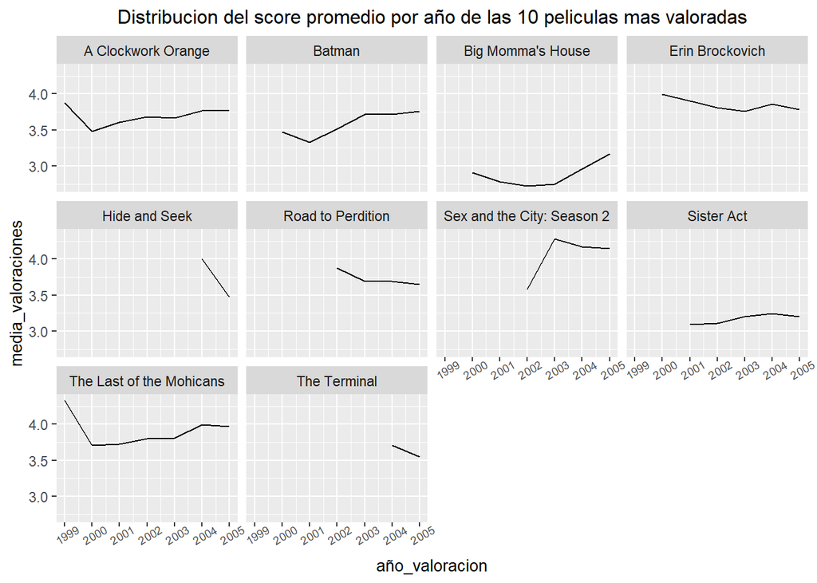

```r
ggplot(top_10_media_por_año) +
  geom_line(mapping = aes(x = año_valoracion, y = media_valoraciones)) +
  facet_wrap(~titulo, nrow = 3) +
  scale_x_continuous(breaks = seq(1999,2005,1), labels = as.integer(seq(1999,2005,1))) +
  labs(title = "Distribucion del score promedio por año de las 10 peliculas mas valoradas") +
  theme(plot.title = element_text(size = 12, hjust = 0.5),
        axis.text.x =  element_text(size = 7, angle = 30),
        axis.title = element_text(size = 10)
        )
```

### 9) Realiza algún gráfico o estudio de estadísticos adicional que consideres informativo en base al análisis exploratorio anterior.

Vamos a analizar cuales son las películas que NO hay que ver. Para ello estudiamos las 10 películas con menor valoración media.

```r
no_ver <- head(arrange(resumen_con_moda, media, desc(media)), 10)

last_10 <- unique(no_ver$titulo)
last_10_peliculas <- subset(peliculas, titulo %in% last_10)
```

#### Media

En el siguiente grafico vemos la media de cada una de las 10 peliculas. Como puede observarse, ninguna de las peliculas alcanza una valoracion de 3, de hecho, solo 6 de las 10 peliculas superan una media de 2 puntos.

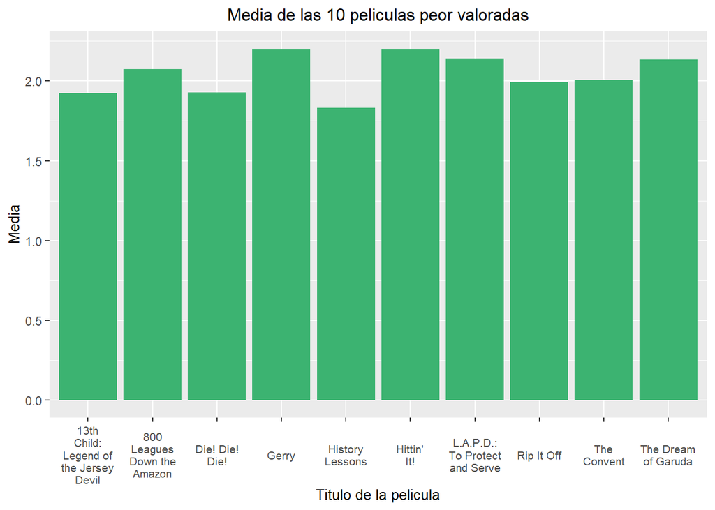

```r
ggplot(no_ver) +
  geom_col(mapping = aes(x = titulo, y = media), stat = "identity", fill= "mediumseagreen", show.legend = F) +
  labs(title = "Media de las 10 peliculas peor valoradas") +
  xlab("Titulo de la pelicula") + ylab("Media") +
  theme(plot.title = element_text(size = 12, hjust = 0.5),
        axis.text.x = element_text(size = 8, vjust = 0.5),
        axis.title = element_text(size = 10)) +
  scale_x_discrete(labels = function(x) str_wrap(x, width = 10))
```

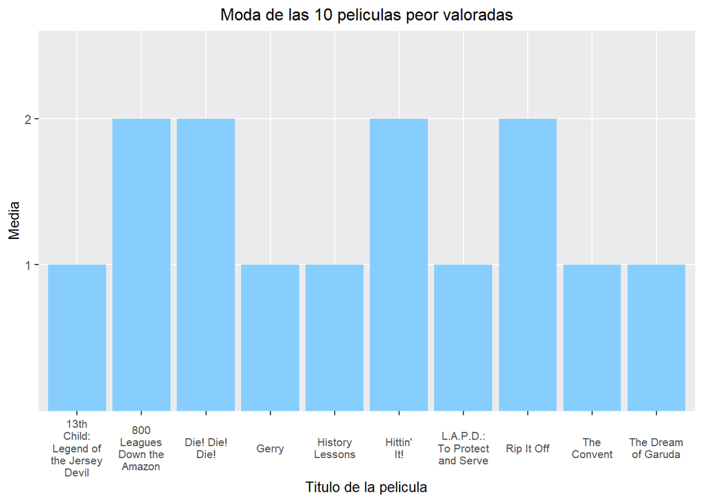

```r
ggplot(no_ver) +
  geom_col(mapping = aes(x = titulo, y = moda), stat = "identity", fill= "skyblue1", show.legend = F) +
  labs(title = "Moda de las 10 peliculas peor valoradas") +
  xlab("Titulo de la pelicula") + ylab("Media") +
  theme(plot.title = element_text(size = 12, hjust = 0.5),
        axis.text.x = element_text(size = 8, vjust = 0.5),
        axis.title = element_text(size = 10)) +
  scale_x_discrete(labels = function(x) str_wrap(x, width = 10))
```

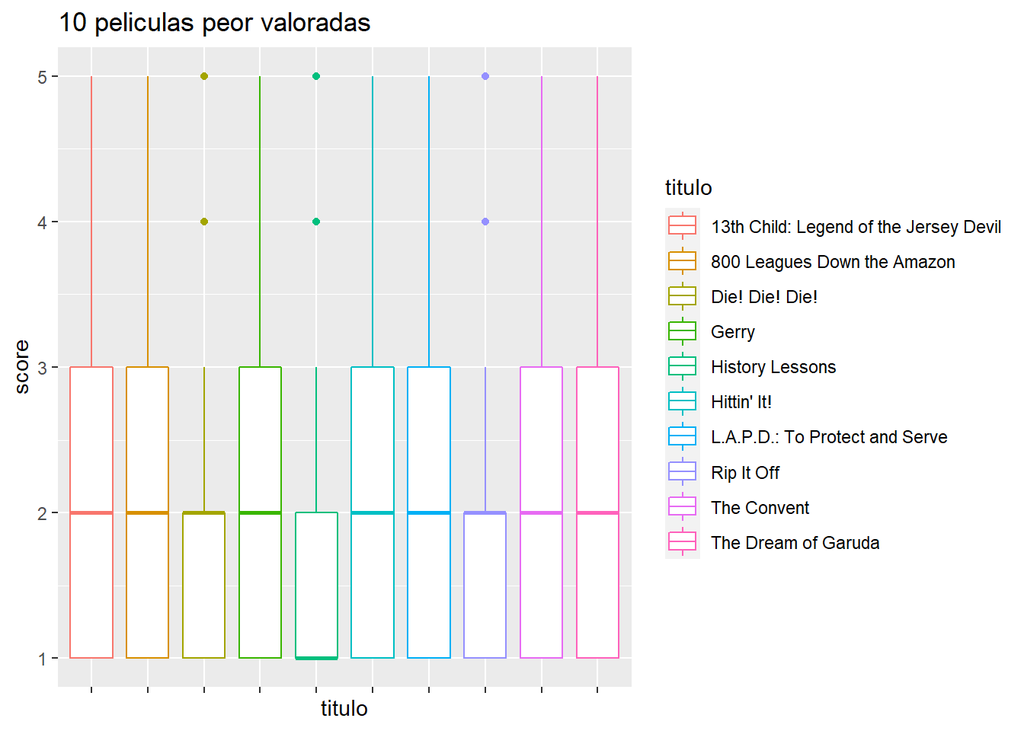

```r
ggplot(last_10_peliculas, aes(x=titulo, y=score, color = titulo)) +
  geom_boxplot() +
  labs(title = "10 peliculas peor valoradas") +
  theme(axis.text.x = element_blank())
```

Dado el análisis de las películas peor valoradas, se puede concluir todas tienen una mediana de 2, excepto “History Lessons”, con una mediana de 1, y una media de 1,83, la más baja de todo el dataset. Por lo tanto, se puede decir que la peor película de las 250 que se han analizado es “History Lessons”.